# Update sélection de variables - clustering des scores fonctionnels - GSCA

Gaspard Martet - unité EPISABE

2026-06-16

```r
library(tidyverse)
library(tseries)
library(openxlsx)
library(FactoMineR)
library(factoextra)
library(ggpubr)
library(RColorBrewer)
library(pheatmap)
library(Hmisc)
library(corrplot)
library(DT)
library(ggrepel)
library(devtools)
library(FonctionsUtiles)
library(lmtest)
library(mixOmics)
library(bestNormalize)
library(kableExtra)
library(fda)
library(funData)
library(reshape2)
library(ggplotify)
library(patchwork)
library(RGCCA)
library(ClustVarLV)
library(ggnewscale)
library(kableExtra)
library(gesca)
```

```r
dat <- openxlsx::read.xlsx("C:/Users/g.martet/Documents/updatedata/dat.xlsx")
dim(dat)
```

```
## [1] 156  98
```

# 1 Introduction

Jusqu’à maintenant, 8 blocks explicatifs étaient considérés, ce qui était beaucoup pour le peu d’individus ($n = 12$ régions) du dataset et donc les modèles perdaient en puissance. De plus, la résistance aux antibiotiques chez les animaux de compagnie et de production n’était pas considérée. Nous allons donc maintenant travailler avec 4 blocks explicatifs: AMC (principale variable d’ajustement pour ce genre d’étude), et trois blocks One Health: Animaux (variable de vétérinaires, du taux de possession d’animaux de compagnie, de densité d’animaux de production et de résistance aux antibiotiques chez eux), environnement (variables de pollution de l’air, résidus de FQ dans l’eau, écarts de température), humain (variables socio-économiques, démographiques, accès au soin, etc.)

# 2 Sélection de variables

La sélection des variables avait déjà été faite, il reste juste à rajouter la résistance chez les animaux.

## 2.1 AMR_EHPAD_FQ_R

On a ici en plus la resistance aux FQ et C3G chez les animaux de production qui ont été rajoutées.

```r
source("C:/Users/g.martet/Documents/firstexploration/Tableau_modlongitudinaux/results_model2.R")

var_to_test <- colnames(dat %>%
                          dplyr::select(-annee, -region, -AMR_EHPAD_C3G_R, -AMR_EHPAD_FQ_R,
                                        -AMR_EHPAD_amoxi_clav_R, -AMR_ville_C3G_R,   -AMR_ville_amoxi_clav_R, -AMR_ville_FQ_R, -AMR_ES_FQ_R, -AMR_ES_amoxi_clav_R, -AMR_ES_C3G_R, -log_AMR_ville_FQ_R))

res2 <- results_model2(var_to_test = var_to_test, Y = "AMR_EHPAD_FQ_R", save_excel = TRUE)
a <- res2[[1]]
b <- res2[[2]]
c <- res2[[3]]

selvar_AMR_EHPAD_FQ <- a %>%
  dplyr::filter(p.value_betaX < 0.05 &
    (is.na(p.value_betaX2) | p.value_betaX2 < 0.05))

DT::datatable(selvar_AMR_EHPAD_FQ) %>%
  formatSignif(columns = 5:11, digits = 3)
```

|  | variable | model_choosen | forme | transformation | betaX | p.value_betaX | betaX2 | p.value_betaX2 | phi | sigma_ind | sigma_res |
| --- | --- | --- | --- | --- | --- | --- | --- | --- | --- | --- | --- |
| alpha | AMR_animaux_production_C3G_R | GEE | lineaire | none | 14.96713933037299 | 0 |  |  | 0.5546820693891538 |  |  |
| alpha1 | AMR_animaux_production_FQ_R | GEE | lineaire | none | 10.57057123594184 | 0 |  |  | 0.5498592388485835 |  |  |
| alpha2 | log_AMC_EHPAD_C3G | GEE | lineaire | none | 2.439729774661873 | 0 |  |  | 0.6319074266516788 |  |  |
| alpha3 | log_AMC_EHPAD_FQ | GEE | lineaire | none | 1.71161784760443 | 0 |  |  | 0.6196302497511271 |  |  |
| alpha4 | log_AMC_EHPAD_macrolides | GEE | lineaire | none | 2.107573776741332 | 0 |  |  | 0.4686909658255326 |  |  |
| alpha5 | log_AMC_EHPAD_penicillines | GEE | lineaire | none | 1.079153052402544 | 0 |  |  | 0.4892071476820865 |  |  |
| alpha6 | log_AMC_EHPAD_tetracyclines | GEE | lineaire | none | -1.442969143563455 | 0 |  |  | 0.5810289680349511 |  |  |
| alpha7 | log_AMC_EHPAD_tot_except_C3G | GEE | lineaire | none | 3.08204161300294 | 0 |  |  | 0.5459257529418527 |  |  |
| alpha8 | log_AMC_EHPAD_totale | GEE | lineaire | none | 3.414614611197573 | 0 |  |  | 0.5541065650594356 |  |  |
| Phi11 | log_AMC_ES_FQ | GLS | lineaire | log_x | 2.931403069461605 | 1.677654445270371e-09 |  |  | 0.681982689409443 |  | 0.7524700526698755 |

[output cut: 36 more lines]

```r
nrow(selvar_AMR_EHPAD_FQ)
```

```
## [1] 46
```

```r
print(selvar_AMR_EHPAD_FQ$variable)
```

```
##  [1] "AMR_animaux_production_C3G_R"   "AMR_animaux_production_FQ_R"
##  [3] "log_AMC_EHPAD_C3G"              "log_AMC_EHPAD_FQ"
##  [5] "log_AMC_EHPAD_macrolides"       "log_AMC_EHPAD_penicillines"
##  [7] "log_AMC_EHPAD_tetracyclines"    "log_AMC_EHPAD_tot_except_C3G"
##  [9] "log_AMC_EHPAD_totale"           "log_AMC_ES_FQ"
## [11] "log_AMC_ES_carba"               "log_AMC_ES_C3G"
## [13] "log_AMC_ES_tot_except_C3G"      "log_AMC_ES_totale"
## [15] "log_AMC_ville_C3G"              "log_AMC_ville_FQ"
## [17] "log_AMC_ville_macrolides"       "log_AMC_ville_penicillines"
## [19] "log_AMC_ville_tetracyclines"    "log_AMC_ville_tmp_sulfa"
## [21] "log_AMC_ville_tot_except_C3G"   "log_AMC_ville_totale"
## [23] "log_AMC_EHPAD_tot_except_FQ"    "log_AMC_ville_tot_except_FQ"
## [25] "log_i041_pib_hab"               "veto_by_AC"
## [27] "veto_by_CV"                     "veto_by_carni"
## [29] "prescri_1"                      "prescri_9_inv"
## [31] "medecin_hab"                    "couv_creche"
## [33] "tx_possession_chats"            "pop_75_plus_prop"
## [35] "air_NO2_pop"                    "air_O3_pop"
## [37] "air_PM10_pop"                   "air_PM25_pop"
## [39] "dju_refroi"                     "log_UGB_density_bovine_all"
## [41] "log_UGB_density_bovins_adultes" "log_UGB_density_livestock_tot"
## [43] "log_UGB_density_porcs"          "log_UGB_density_veaux"
## [45] "log_UGB_density_volailles"      "i007b_part_agribio_surf"
```

## 2.2 AMR_ES_FQ_R

On a ici en plus la resistance aux C3G chez les animaux de compagnie et la résistance à l’amoxicilinne chez les animaux de production.

```r
res2 <- results_model2(var_to_test = var_to_test, Y = "AMR_ES_FQ_R", save_excel = TRUE)
a <- res2[[1]]
b <- res2[[2]]
c <- res2[[3]]

selvar_AMR_ES_FQ <- a %>%
  dplyr::filter(p.value_betaX < 0.05 &
    (is.na(p.value_betaX2) | p.value_betaX2 < 0.05))

DT::datatable(selvar_AMR_ES_FQ) %>%
  formatSignif(columns = 5:11, digits = 3)
```

|  | variable | model_choosen | forme | transformation | betaX | p.value_betaX | betaX2 | p.value_betaX2 | phi | sigma_ind | sigma_res |
| --- | --- | --- | --- | --- | --- | --- | --- | --- | --- | --- | --- |
| alpha | AMR_animaux_compagnie_C3G_R | GEE | lineaire | none | 2.627577892686297 | 0 |  |  | 0.5637459360875778 |  |  |
| Phi4 | AMR_animaux_production_amoxi_clav_R | LMM | quadratique | arcsinh_x | -9.954125179921126 | 0.01085254062327959 | 10.07779798091481 | 0.04065577160806066 | -0.1120696102512888 | 1.0608774 | 0.2839084 |
| Phi11 | log_AMC_EHPAD_C3G | GLS | lineaire | center_scale | 1.360551246731813 | 0.0001232684294778308 |  |  | 0.9283732118046039 |  | 0.9952967980309512 |
| alpha1 | log_AMC_EHPAD_FQ | GEE | lineaire | none | 1.105309273463586 | 0 |  |  | 0.6245409422608447 |  |  |
| alpha2 | log_AMC_EHPAD_macrolides | GEE | lineaire | none | 1.61888282958648 | 0 |  |  | 0.5745729041888569 |  |  |
| alpha3 | log_AMC_EHPAD_penicillines | GEE | lineaire | none | 1.089532210478336 | 0 |  |  | 0.5843641745834798 |  |  |
| alpha4 | log_AMC_EHPAD_tetracyclines | GEE | lineaire | none | -1.49902399266706 | 0 |  |  | 0.6034988858305599 |  |  |
| alpha5 | log_AMC_EHPAD_tmp_sulfa | GEE | lineaire | none | 2.47296366050328 | 0 |  |  | 0.5881634451256939 |  |  |
| alpha6 | log_AMC_EHPAD_tot_except_C3G | GEE | lineaire | none | 1.072934170150479 | 0 |  |  | 0.5621442399524813 |  |  |
| alpha7 | log_AMC_EHPAD_totale | GEE | lineaire | none | 1.257126437641911 | 0 |  |  | 0.5622612962712906 |  |  |

[output cut: 46 more lines]

```r
nrow(selvar_AMR_ES_FQ)
```

```
## [1] 56
```

```r
print(selvar_AMR_ES_FQ$variable)
```

```
##  [1] "AMR_animaux_compagnie_C3G_R"         "AMR_animaux_production_amoxi_clav_R"
##  [3] "log_AMC_EHPAD_C3G"                   "log_AMC_EHPAD_FQ"
##  [5] "log_AMC_EHPAD_macrolides"            "log_AMC_EHPAD_penicillines"
##  [7] "log_AMC_EHPAD_tetracyclines"         "log_AMC_EHPAD_tmp_sulfa"
##  [9] "log_AMC_EHPAD_tot_except_C3G"        "log_AMC_EHPAD_totale"
## [11] "log_AMC_ES_carba"                    "log_AMC_ES_C3G"
## [13] "log_AMC_ES_tot_except_C3G"           "log_AMC_ES_totale"
## [15] "log_AMC_ville_FQ"                    "log_AMC_ville_macrolides"
## [17] "log_AMC_ville_penicillines"          "log_AMC_ville_tetracyclines"
## [19] "log_AMC_ville_tmp_sulfa"             "log_AMC_ville_tot_except_C3G"
## [21] "log_AMC_ville_totale"                "log_AMC_EHPAD_tot_except_FQ"
## [23] "log_AMC_ES_tot_except_FQ"            "log_AMC_ville_tot_except_FQ"
## [25] "EQI_st"                              "log_i041_pib_hab"
## [27] "prop_travail_manuel"                 "tx_pauvrete_60"
## [29] "unemployement_pourc"                 "veto_by_CV"
## [31] "prescri_1"                           "APL_medG"
## [33] "medecin_hab"                         "prop_appart"
## [35] "couv_creche"                         "tx_possession_chats"
## [37] "tx_possession_chevaux"               "tx_possession_chiens"
## [39] "pop_14_moins_prop"                   "pop_3_moins_prop"
## [41] "pop_75_plus_prop"                    "log_pop_density"
## [43] "air_NO2_pop"                         "air_O3_pop"
## [45] "air_PM10_pop"                        "air_PM25_pop"
## [47] "dju_refroi"                          "log_i033a_part_class_5_eau_sup_nit"
## [49] "log_UGB_density_SAU_bovine_all"      "log_UGB_density_bovine_all"
## [51] "log_UGB_density_bovins_adultes"      "log_UGB_density_livestock_tot"
## [53] "log_UGB_density_ovins"               "log_UGB_density_porcs"
## [55] "log_UGB_density_veaux"               "log_UGB_density_volailles"
```

## 2.3 AMR_ville_FQ_R

A part l’AMR à l’amoxicilinne chez les animaux de compagnie, toutes les variables d’AMR des animaux ont été sélectionées.

```r
res2 <- results_model2(var_to_test = var_to_test, Y = "AMR_ville_FQ_R", save_excel = TRUE)
a <- res2[[1]]
b <- res2[[2]]
c <- res2[[3]]

selvar_AMR_ville_FQ <- a %>%
  dplyr::filter(p.value_betaX < 0.05 &
    (is.na(p.value_betaX2) | p.value_betaX2 < 0.05))

DT::datatable(selvar_AMR_ville_FQ) %>%
  formatSignif(columns = 5:11, digits = 3)
```

|  | variable | model_choosen | forme | transformation | betaX | p.value_betaX | betaX2 | p.value_betaX2 | phi | sigma_ind | sigma_res |
| --- | --- | --- | --- | --- | --- | --- | --- | --- | --- | --- | --- |
| alpha | AMR_animaux_compagnie_C3G_R | GEE | lineaire | none | 8.447274884480168 | 0 |  |  | 0.6790199744837764 |  |  |
| alpha1 | AMR_animaux_compagnie_FQ_R | GEE | lineaire | none | 8.73576995730841 | 0 |  |  | 0.6263476778988265 |  |  |
| alpha2 | AMR_animaux_production_C3G_R | GEE | lineaire | none | 10.93261598113343 | 0 |  |  | 0.6966696373483322 |  |  |
| alpha3 | AMR_animaux_production_FQ_R | GEE | lineaire | none | 13.12349072731382 | 0 |  |  | 0.7110294899517242 |  |  |
| alpha4 | AMR_animaux_production_amoxi_clav_R | GEE | lineaire | none | -0.1591959463102448 | 0 |  |  | 0.6634780319120802 |  |  |
| alpha5 | log_AMC_EHPAD_C3G | GEE | lineaire | none | 1.912501553655831 | 0 |  |  | 0.6430966660611218 |  |  |
| alpha6 | log_AMC_EHPAD_FQ | GEE | lineaire | none | 1.483477134940044 | 0 |  |  | 0.6766441505653067 |  |  |
| alpha7 | log_AMC_EHPAD_macrolides | GEE | lineaire | none | 1.585494296024169 | 0 |  |  | 0.5468105852279537 |  |  |
| alpha8 | log_AMC_EHPAD_penicillines | GEE | lineaire | none | -0.1182637700985531 | 0 |  |  | 0.5999036634863664 |  |  |
| alpha9 | log_AMC_EHPAD_tmp_sulfa | GEE | lineaire | none | 0.3633657701165754 | 0 |  |  | 0.6583958384573516 |  |  |

[output cut: 51 more lines]

```r
nrow(selvar_AMR_ville_FQ)
```

```
## [1] 61
```

```r
print(selvar_AMR_ville_FQ$variable)
```

```
##  [1] "AMR_animaux_compagnie_C3G_R"         "AMR_animaux_compagnie_FQ_R"
##  [3] "AMR_animaux_production_C3G_R"        "AMR_animaux_production_FQ_R"
##  [5] "AMR_animaux_production_amoxi_clav_R" "log_AMC_EHPAD_C3G"
##  [7] "log_AMC_EHPAD_FQ"                    "log_AMC_EHPAD_macrolides"
##  [9] "log_AMC_EHPAD_penicillines"          "log_AMC_EHPAD_tmp_sulfa"
## [11] "log_AMC_EHPAD_tot_except_C3G"        "log_AMC_EHPAD_totale"
## [13] "log_AMC_ES_FQ"                       "log_AMC_ES_carba"
## [15] "log_AMC_ES_C3G"                      "log_AMC_ES_tot_except_C3G"
## [17] "log_AMC_ES_totale"                   "log_AMC_ville_C3G"
## [19] "log_AMC_ville_FQ"                    "log_AMC_ville_macrolides"
## [21] "log_AMC_ville_penicillines"          "log_AMC_ville_tetracyclines"
## [23] "log_AMC_ville_tmp_sulfa"             "log_AMC_ville_tot_except_C3G"
## [25] "log_AMC_ville_totale"                "log_AMC_EHPAD_tot_except_FQ"
## [27] "log_AMC_ES_tot_except_FQ"            "log_AMC_ville_tot_except_FQ"
## [29] "EQI_st"                              "bac_ou_plus_20_64"
```

[output cut: 16 more lines]

## 2.4 AMR_EHPAD_C3G_R

La resistance aux C3G et FQ chez les animaux de production ainsi que celle à l’amoxicilinne chez les animaux de compagnie ont été rajoutées.

```r
res2 <- results_model2(var_to_test = var_to_test, Y = "AMR_EHPAD_C3G_R", save_excel = TRUE)
a <- res2[[1]]
b <- res2[[2]]
c <- res2[[3]]

selvar_AMR_EHPAD_C3G <- a %>%
  dplyr::filter(p.value_betaX < 0.05 &
    (is.na(p.value_betaX2) | p.value_betaX2 < 0.05))

DT::datatable(selvar_AMR_EHPAD_C3G) %>%
  formatSignif(columns = 5:11, digits = 3)
```

|  | variable | model_choosen | forme | transformation | betaX | p.value_betaX | betaX2 | p.value_betaX2 | phi | sigma_ind | sigma_res |
| --- | --- | --- | --- | --- | --- | --- | --- | --- | --- | --- | --- |
| alpha | AMR_animaux_compagnie_amoxi_clav_R | GEE | lineaire | none | -0.3546441862215106 | 0 |  |  | 0.6361188508917185 |  |  |
| alpha1 | AMR_animaux_production_C3G_R | GEE | lineaire | none | -1.983376246058253 | 0 |  |  | 0.6282639362506176 |  |  |
| alpha2 | AMR_animaux_production_FQ_R | GEE | lineaire | none | 6.344202955837227 | 0 |  |  | 0.6491883942321581 |  |  |
| alpha3 | log_AMC_EHPAD_C3G | GEE | lineaire | none | 0.7925124219524856 | 0 |  |  | 0.6762790691938041 |  |  |
| alpha4 | log_AMC_EHPAD_FQ | GEE | lineaire | none | 0.3945630045137095 | 0 |  |  | 0.6842983849409863 |  |  |
| alpha5 | log_AMC_EHPAD_macrolides | GEE | lineaire | none | 2.642056645354504 | 0 |  |  | 0.6291949092825833 |  |  |
| alpha6 | log_AMC_EHPAD_penicillines | GEE | lineaire | none | 0.7807942602735223 | 0 |  |  | 0.6374447388928974 |  |  |
| alpha7 | log_AMC_EHPAD_tmp_sulfa | GEE | lineaire | none | 0.4951922880034321 | 0 |  |  | 0.6284410907257748 |  |  |
| alpha8 | log_AMC_EHPAD_tot_except_C3G | GEE | lineaire | none | 2.98812896519863 | 0 |  |  | 0.5954303701266498 |  |  |
| alpha9 | log_AMC_EHPAD_totale | GEE | lineaire | none | 3.377585284539667 | 0 |  |  | 0.6009337693353586 |  |  |

[output cut: 33 more lines]

```r
nrow(selvar_AMR_EHPAD_C3G)
```

```
## [1] 43
```

```r
print(selvar_AMR_EHPAD_C3G$variable)
```

```
##  [1] "AMR_animaux_compagnie_amoxi_clav_R" "AMR_animaux_production_C3G_R"
##  [3] "AMR_animaux_production_FQ_R"        "log_AMC_EHPAD_C3G"
##  [5] "log_AMC_EHPAD_FQ"                   "log_AMC_EHPAD_macrolides"
##  [7] "log_AMC_EHPAD_penicillines"         "log_AMC_EHPAD_tmp_sulfa"
##  [9] "log_AMC_EHPAD_tot_except_C3G"       "log_AMC_EHPAD_totale"
## [11] "log_AMC_ES_FQ"                      "log_AMC_ES_carba"
## [13] "log_AMC_ES_tot_except_C3G"          "log_AMC_ES_totale"
## [15] "log_AMC_ville_macrolides"           "log_AMC_ville_penicillines"
## [17] "log_AMC_ville_tetracyclines"        "log_AMC_ville_tmp_sulfa"
## [19] "log_AMC_ville_tot_except_C3G"       "log_AMC_ville_totale"
## [21] "log_AMC_EHPAD_tot_except_FQ"        "log_AMC_ville_tot_except_FQ"
## [23] "log_i041_pib_hab"                   "prop_travail_manuel"
## [25] "veto_by_CV"                         "APL_medG"
## [27] "medecin_hab"                        "prop_alcool"
## [29] "couv_creche"                        "tx_possession_chats"
## [31] "tx_possession_chevaux"              "tx_possession_chiens"
## [33] "pop_75_plus_prop"                   "log_pop_density"
## [35] "air_NO2_pop"                        "air_O3_pop"
## [37] "air_PM10_pop"                       "air_PM25_pop"
## [39] "dju_refroi"                         "log_UGB_density_ovins"
## [41] "log_UGB_density_veaux"              "log_UGB_density_volailles"
## [43] "i007b_part_agribio_surf"
```

## 2.5 AMR_ES_C3G_R

La resistance aux C3G et FQ chez les animaux de production ont été rajoutées.

```r
res2 <- results_model2(var_to_test = var_to_test, Y = "AMR_ES_C3G_R", save_excel = TRUE)
a <- res2[[1]]
b <- res2[[2]]
c <- res2[[3]]

selvar_AMR_ES_C3G <- a %>%
  dplyr::filter(p.value_betaX < 0.05 &
    (is.na(p.value_betaX2) | p.value_betaX2 < 0.05))

DT::datatable(selvar_AMR_ES_C3G) %>%
  formatSignif(columns = 5:11, digits = 3)
```

|  | variable | model_choosen | forme | transformation | betaX | p.value_betaX | betaX2 | p.value_betaX2 | phi | sigma_ind | sigma_res |
| --- | --- | --- | --- | --- | --- | --- | --- | --- | --- | --- | --- |
| Phi13 | AMR_animaux_production_C3G_R | LMM | quadratique | orderNorm | 28.63521163877465 | 0.02625599641498295 | -286.6712137285579 | 0.04101767514755283 | 0.7420325736156324 | 6.574773e-05 | 1.018823 |
| alpha | AMR_animaux_production_FQ_R | GEE | lineaire | none | 13.31723065209971 | 0 |  |  | 0.5128966281146202 |  |  |
| alpha1 | log_AMC_EHPAD_C3G | GEE | lineaire | none | 1.450236665730419 | 0 |  |  | 0.516206395684378 |  |  |
| alpha2 | log_AMC_EHPAD_FQ | GEE | lineaire | none | 0.9980912449386945 | 0 |  |  | 0.4671325694325126 |  |  |
| Phi113 | log_AMC_EHPAD_tetracyclines | GLS | lineaire | orderNorm | -2.225960072960168 | 0.001164042347846479 |  |  | 0.724361256285448 |  | 0.9615855575602776 |
| alpha3 | log_AMC_EHPAD_tmp_sulfa | GEE | lineaire | none | -0.5850817351766648 | 0 |  |  | 0.4135872466806868 |  |  |
| alpha4 | log_AMC_EHPAD_tot_except_C3G | GEE | lineaire | none | 4.53678940369493 | 0 |  |  | 0.5020315334418688 |  |  |
| alpha5 | log_AMC_EHPAD_totale | GEE | lineaire | none | 4.771254926348947 | 0 |  |  | 0.5266370816574597 |  |  |
| alpha6 | log_AMC_ES_FQ | GEE | lineaire | none | 2.207114248676829 | 0 |  |  | 0.4558929089545747 |  |  |
| alpha7 | log_AMC_ES_carba | GEE | lineaire | none | 0.5735252999764466 | 0 |  |  | 0.1887340097654339 |  |  |

[output cut: 38 more lines]

```r
nrow(selvar_AMR_ES_C3G)
```

```
## [1] 48
```

```r
print(selvar_AMR_ES_C3G$variable)
```

```
##  [1] "AMR_animaux_production_C3G_R"   "AMR_animaux_production_FQ_R"
##  [3] "log_AMC_EHPAD_C3G"              "log_AMC_EHPAD_FQ"
##  [5] "log_AMC_EHPAD_tetracyclines"    "log_AMC_EHPAD_tmp_sulfa"
##  [7] "log_AMC_EHPAD_tot_except_C3G"   "log_AMC_EHPAD_totale"
##  [9] "log_AMC_ES_FQ"                  "log_AMC_ES_carba"
## [11] "log_AMC_ES_C3G"                 "log_AMC_ES_totale"
## [13] "log_AMC_ville_C3G"              "log_AMC_ville_FQ"
## [15] "log_AMC_ville_macrolides"       "log_AMC_ville_penicillines"
## [17] "log_AMC_ville_tetracyclines"    "log_AMC_ville_tot_except_C3G"
## [19] "log_AMC_ville_totale"           "log_AMC_EHPAD_tot_except_FQ"
## [21] "log_AMC_ES_tot_except_FQ"       "log_AMC_ville_tot_except_FQ"
## [23] "bac_ou_plus_20_64"              "log_i041_pib_hab"
## [25] "prop_immig"                     "tx_pauvrete_60"
## [27] "unemployement_pourc"            "veto_by_AC"
## [29] "veto_by_CV"                     "prescri_1"
## [31] "prop_veto_50plus"               "APL_medG"
## [33] "medecin_hab"                    "prop_appart"
## [35] "couv_creche"                    "tx_possession_chats"
## [37] "tx_possession_chevaux"          "air_NO2_pop"
## [39] "air_O3_pop"                     "air_PM10_pop"
## [41] "air_PM25_pop"                   "dju_refroi"
## [43] "log_UGB_density_bovine_all"     "log_UGB_density_bovins_adultes"
## [45] "log_UGB_density_lapins"         "log_UGB_density_livestock_tot"
## [47] "log_UGB_density_veaux"          "log_UGB_density_volailles"
```

## 2.6 AMR_ville_C3G_R

La resistance aux C3G et FQ chez les animaux de production et celle à l’amoxicilinne chez les animaux de compagnie ont été rajoutées.

```r
res2 <- results_model2(var_to_test = var_to_test, Y = "AMR_ville_C3G_R", save_excel = TRUE)
a <- res2[[1]]
b <- res2[[2]]
c <- res2[[3]]

selvar_AMR_ville_C3G <- a %>%
  dplyr::filter(p.value_betaX < 0.05 &
    (is.na(p.value_betaX2) | p.value_betaX2 < 0.05))

DT::datatable(selvar_AMR_ville_C3G) %>%
  formatSignif(columns = 5:11, digits = 3)
```

|  | variable | model_choosen | forme | transformation | betaX | p.value_betaX | betaX2 | p.value_betaX2 | phi | sigma_ind | sigma_res |
| --- | --- | --- | --- | --- | --- | --- | --- | --- | --- | --- | --- |
| alpha | AMR_animaux_compagnie_amoxi_clav_R | GEE | lineaire | none | -0.3972566724827555 | 0 |  |  | 0.6065312111948491 |  |  |
| alpha1 | AMR_animaux_production_C3G_R | GEE | lineaire | none | -2.827891921100693 | 0 |  |  | 0.5967645552238307 |  |  |
| Phi2 | AMR_animaux_production_FQ_R | LMM | quadratique | orderNorm | 15.66748978221496 | 0.03643128694025849 | -116.9093717488486 | 0.003405878887281595 | 0.7380822924234625 | 0.0001235796 | 0.9987801631 |
| alpha2 | log_AMC_EHPAD_FQ | GEE | lineaire | none | 0.08722460999112452 | 0 |  |  | 0.6047968832940616 |  |  |
| alpha3 | log_AMC_EHPAD_macrolides | GEE | lineaire | none | 1.802854499903299 | 0 |  |  | 0.5537455138400669 |  |  |
| alpha4 | log_AMC_EHPAD_penicillines | GEE | lineaire | none | -0.2302218926762622 | 0 |  |  | 0.2740967151125348 |  |  |
| alpha5 | log_AMC_ES_FQ | GEE | lineaire | none | 0.8463180588709893 | 0 |  |  | 0.5741714235579812 |  |  |
| alpha6 | log_AMC_ES_carba | GEE | lineaire | none | 1.140882425301271 | 0 |  |  | 0.3627071662365109 |  |  |
| alpha7 | log_AMC_ES_C3G | GEE | lineaire | none | 0.2245697864732948 | 0 |  |  | 0.4526325872816895 |  |  |
| alpha8 | log_AMC_ES_totale | GEE | lineaire | none | 1.299559840947183 | 0 |  |  | 0.5495859118001585 |  |  |

[output cut: 25 more lines]

```r
nrow(selvar_AMR_ville_C3G)
```

```
## [1] 35
```

```r
print(selvar_AMR_ville_C3G$variable)
```

```
##  [1] "AMR_animaux_compagnie_amoxi_clav_R" "AMR_animaux_production_C3G_R"
##  [3] "AMR_animaux_production_FQ_R"        "log_AMC_EHPAD_FQ"
##  [5] "log_AMC_EHPAD_macrolides"           "log_AMC_EHPAD_penicillines"
##  [7] "log_AMC_ES_FQ"                      "log_AMC_ES_carba"
##  [9] "log_AMC_ES_C3G"                     "log_AMC_ES_totale"
## [11] "log_AMC_ville_macrolides"           "log_AMC_ville_tetracyclines"
## [13] "log_AMC_ville_tot_except_C3G"       "log_AMC_ville_totale"
## [15] "log_AMC_ES_tot_except_FQ"           "log_AMC_ville_tot_except_FQ"
## [17] "bac_ou_plus_20_64"                  "log_i041_pib_hab"
## [19] "prop_travail_manuel"                "tx_pauvrete_60"
## [21] "unemployement_pourc"                "veto_by_CV"
## [23] "APL_medG"                           "medecin_hab"
## [25] "prop_tabagisme"                     "couv_creche"
## [27] "pop_3_moins_prop"                   "air_NO2_pop"
## [29] "air_O3_pop"                         "air_PM10_pop"
## [31] "air_PM25_pop"                       "dju_refroi"
## [33] "log_UGB_density_livestock_tot"      "log_UGB_density_porcs"
## [35] "log_UGB_density_volailles"
```

## 2.7 Tableau récapitulatif

| block | variables_candidates | AMR_EHPAD_FQ_R | AMR_ES_FQ_R | AMR_ville_FQ_R |
| --- | --- | --- | --- | --- |
| AMC | 28 | 24 | 23 | 24 |
| Animals | 28 | 13 | 14 | 19 |
| Environment | 11 | 5 | 6 | 7 |
| Humans | 19 | 4 | 13 | 11 |
| Total | 86 | 46 | 56 | 61 |

## 2.8 Tableau récapitulatif C3G

| block | variables_candidates | AMR_EHPAD_C3G_R | AMR_ES_C3G_R | AMR_ville_C3G_R |
| --- | --- | --- | --- | --- |
| AMC | 28 | 19 | 21 | 13 |
| Animals | 28 | 11 | 13 | 7 |
| Environment | 11 | 5 | 5 | 5 |
| Humans | 19 | 8 | 9 | 10 |
| Total | 86 | 43 | 48 | 35 |

# 3 Corrélations fonctionelles

## 3.1 AMR_EHPAD_FQ_R

```r
blocks <- levels(as.factor(correspondance_block$block))

y <- "AMR_EHPAD_FQ_R"
#time_period <- 2018:2022
var <- selvar_AMR_EHPAD_FQ$variable
Nb.Base <- 5

K = c(NA, 4, NA, NA)
automatisation_block <- function(y, blocks, var, Nb.Base,
                                 K_choice = NULL, metd){
# dataset des composantes fonctionelles de chaque variables
sum.var <- data.frame(col_to_suppr = rep(NA, 12))
# dataset des clsuter de chaque variables
cls.var <- data.frame(variable = character(),
                      var2 = character())
colnames(cls.var)[2] <- y
# la boucle
for (i in 1:length(blocks)) {

cat(paste0("\n\n### ", blocks[i], "\n\n"))

res <- functional_correlation(var = var,
                       block = blocks[i], y = y,
                       Nb.Base = Nb.Base)

print(DT::datatable(res[[1]]))

# classification des variables CLV
var.clv <- res[[6]]
var.clv <- var.clv[, -which(colnames(var.clv) %in% y)]

cls.var2 <- data.frame(variable = character(),
                      var2 = character())
if (is.na(K_choice[i])){
if (ncol(var.clv) <= 2){
  d <- data.frame(variable = colnames(var.clv),
                  var2 = paste0("cluster_", 1:ncol(var.clv)))
  cls.var2 <- rbind.data.frame(cls.var2, d)
} else if (ncol(var.clv) > 2 & ncol(var.clv) <= 5){
  res.clv <- ClustVarLV::CLV(var.clv,
                             method = metd,
                             sX = TRUE,
                             maxiter = 50,
                             graph = FALSE)
  res.clv2 <- ClustVarLV::get_partition(res.clv, K = 2)
  d <- data.frame(variable = names(res.clv2),
                  var2 = paste0("cluster_", res.clv2))
  cls.var2 <- rbind.data.frame(cls.var2, d)
} else {
  res.clv <- ClustVarLV::CLV(var.clv,
                             method = metd,
                             sX = TRUE,
                             maxiter = 50,
                             graph = FALSE)
  d <- as.data.frame(res.clv$tabres)
  l <- c()
  for (i in 0:(nrow(d)-1)){
    l <- c(l, d$agg.crit.hac[nrow(d)-i] - d$agg.crit.hac[nrow(d)-(i+1)])}
  K = which.max(l)+1
  res.clv2 <- ClustVarLV::get_partition(res.clv, K = K)
  d <- data.frame(variable = names(res.clv2),
                  var2 = paste0("cluster_", res.clv2))
  cls.var2 <- rbind.data.frame(cls.var2, d)
}}
else{
res.clv <- ClustVarLV::CLV(var.clv,
                             method = metd,
                             sX = TRUE,
                             maxiter = 50,
                             graph = FALSE)
d <- as.data.frame(res.clv$tabres)

res.clv2 <- ClustVarLV::get_partition(res.clv, K = K_choice[i])
d <- data.frame(variable = names(res.clv2),
                  var2 = paste0("cluster_", res.clv2))
cls.var2 <- rbind.data.frame(cls.var2, d)}


colnames(cls.var2)[2] <- y
cls.var <- rbind.data.frame(cls.var, cls.var2)

# la heatmap des PC1 fonctionelles

d <- data.frame(variable = y,
                var2 = "Y")
colnames(d)[2] <- y
cls.var2 <- rbind.data.frame(cls.var2, d)
cls.var2 <- tibble::column_to_rownames(cls.var2, var = "variable")
colnames(cls.var2) <- "cluster CLV"

ph2 <- pheatmap::pheatmap(res[[2]],
                          color = colorRampPalette(c("blue", "grey80", "red"))(100),
                          breaks = seq(-1, 1, length.out = 101),
                          cluster_rows = TRUE,
                          cluster_cols = TRUE,
                          clustering_distance_rows = "euclidean",
                          clustering_distance_cols = "euclidean",
                          clustering_method = "ward.D2",
                          number_format = "%.1f",
                          fontsize = 7,
                          number_color = "white",
                          legend = TRUE,
                          display_numbers = res[[5]],
                          legend_breaks = c(-1, -0.5, 0, 0.5, 1),
                          legend_labels = c("-1", "-0.5", "0", "0.5", "1"),
                          angle_col = 45,
                          annotation_row = cls.var2,
                          annotation_col = cls.var2,
                          main = "Premières composantes fonctionnelles",
                          silent = TRUE)

sum.var <- cbind.data.frame(sum.var, res[[6]])

# ACP
out.pca <- FactoMineR::PCA(res[[6]], graph = FALSE)
g2 <- factoextra::fviz_pca_biplot(out.pca, repel = TRUE, labelsize = 2,
                                  title = "Biplot PCA classique sur les PC1 fonctionelles des variables")+
  theme(plot.title = element_text(hjust = 0.5, size = 7),
        axis.text = element_text(color = "black", size = 7),
        axis.title = element_text(size = 7))

Y <- as.matrix(res[[6]][,which(colnames(res[[6]]) %in% y)])
X <- as.matrix(res[[6]][,which(!colnames(res[[6]]) %in% y)])

# régression PLS

# Nombre de composantes sûr (si jamais un block avec une seule variable)

# RGCCA attend une liste de blocs
bl <- list(X = X, Y = Y)

out.pls <- rgcca(
  blocks    = bl,
  method = "pls",
  ncomp = 2
)

comp1_var <- out.pls$AVE$AVE_X[["X"]][1]
comp2_var <- out.pls$AVE$AVE_X[["X"]][2]

# Corrélations variables X avec les composantes
scores_X  <- out.pls$Y[["X"]]   # scores du bloc X
loadings_cor_X <- cor(X, scores_X)
# Corrélations variables Y avec les mêmes composantes
loadings_cor_Y <- cor(Y, scores_X)

circos <- data.frame(
  x     = c(loadings_cor_X[, 1], loadings_cor_Y[, 1]),
  y     = c(loadings_cor_X[, 2], loadings_cor_Y[, 2]),
  names = c(rownames(loadings_cor_X), y),
  Block = c(rep("X", nrow(loadings_cor_X)), rep("Y", nrow(loadings_cor_Y)))
)

ind <- data.frame(
  x    = out.pls$Y[["X"]][, 1],
  y    = out.pls$Y[["X"]][, 2],
  name = rownames(out.pls$Y[["X"]]),
  Y    = res[[6]][, y]
)

#dev.off() # pour fermer le device si nécessaire

circleFun <- function(center = c(0,0), diameter = 2, npoints = 100) {
  r = diameter/2
  tt <- seq(0, 2*pi,length.out = npoints)
  data.frame(x = center[1] + r*cos(tt), y = center[2] + r*sin(tt))
}
circle <- rbind(circleFun(diameter = 2), circleFun(diameter = 1))

g3 <- ggplot(circos, aes(x = x, y = y, col = Block)) +
  geom_path(aes(x, y), data = circle, col = "gray60", size = .2, inherit.aes = FALSE) +
  geom_vline(xintercept = 0, col = "gray60", size = .3) +
  geom_hline(yintercept = 0, col = "gray60", size = .3) +
  geom_segment(aes(x = 0, y = 0, xend = x, yend = y),
               arrow = arrow(length = unit(0.2, "cm"), type = "closed"),
               linewidth = 0.5, show.legend = FALSE) +
  geom_text_repel(aes(label = names), size = 1.7, segment.size = 0.1,
                  segment.color = "grey50", max.overlaps = 35, show.legend = FALSE) +
  scale_colour_manual(values = c("X" = "steelblue", "Y" = "red4"),
                      name = "Block") +
  ggnewscale::new_scale_colour() +
  geom_point(data = ind, aes(x = x, y = y, colour = Y), size = 1.5, shape = 17, inherit.aes = FALSE) +
  geom_text_repel(data = ind, aes(x = x, y = y, label = name, colour = Y),
                  size = 1.7, segment.size = 0.1,
                  segment.color = "grey50", max.overlaps = 35, inherit.aes = FALSE) +
  scale_colour_gradient(low = "blue", high = "red", name = "PC1 Y") +
  coord_fixed() +
  labs(title = "Regression PLS - biplot",
       x = paste0("Dim 1 (", round(comp1_var*100, 2), "%)"),
       y = paste0("Dim 2 (", round(comp2_var*100, 2), "%)")) +
  theme_minimal(base_size = 5) +
  theme(
    plot.title = element_text(hjust = 0.5, size = 7),
    axis.text = element_text(color = "black", size = 7),
    axis.title = element_text(size = 7),
    legend.position = "right",
    legend.margin = margin(t = -8),
    legend.spacing.x = unit(0.2, "cm"),
    legend.key.width = unit(0.3, "lines"),
    legend.title = element_text(size = 7),
    legend.text = element_text(margin = margin(l = 1)),
    panel.grid = element_line(linewidth = .1)
  )


# Convertir le pheatmap en grob
ph2_grob <- patchwork::wrap_elements(ph2$gtable)

# Assembler les trois graphiques
# Option 1 : disposition en L (heatmap à gauche, biplots empilés à droite)
layout <- "
AA
BC
"

combined <- ph2_grob + g2 + g3 +
  plot_layout(design = layout, heights = c(1.8, 1)) +
  plot_annotation(
    title = paste0("Analyse fonctionnelle - ", y),
    theme = theme(plot.title = element_text(hjust = 0.5, size = 10))
  )

print(combined)

}

#sum.var <- sum.var[,-which(duplicated(colnames(sum.var)))]
sum.var <- sum.var[, colnames(sum.var) != "col_to_suppr", drop = FALSE]

openxlsx::write.xlsx(sum.var, file = paste0("sum.var_", y, ".xlsx"), rowNames = TRUE)
openxlsx::write.xlsx(cls.var, file = paste0("cls.var_", y, ".xlsx"), rowNames = FALSE)

}

K = c(3, 4, NA, NA)
automatisation_block(y = y, blocks = blocks, var = var,
                     Nb.Base = Nb.Base, K_choice = K, metd = "directional")
```

### 3.1.1 AMC

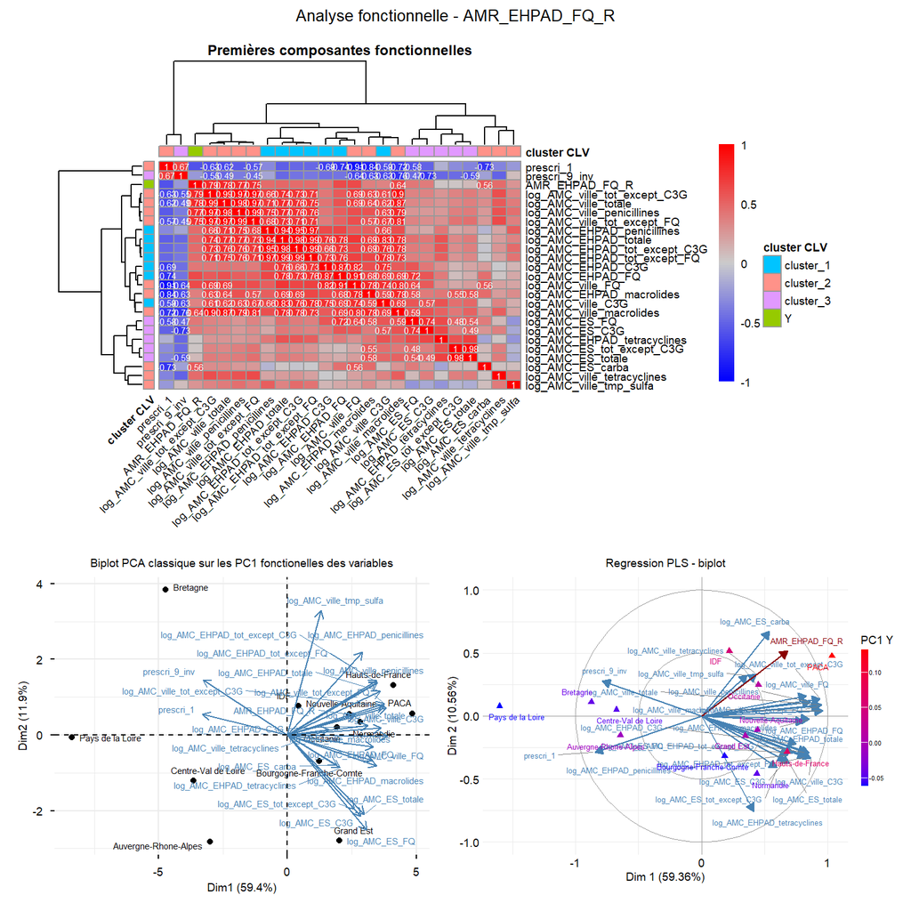

### 3.1.2 Animals

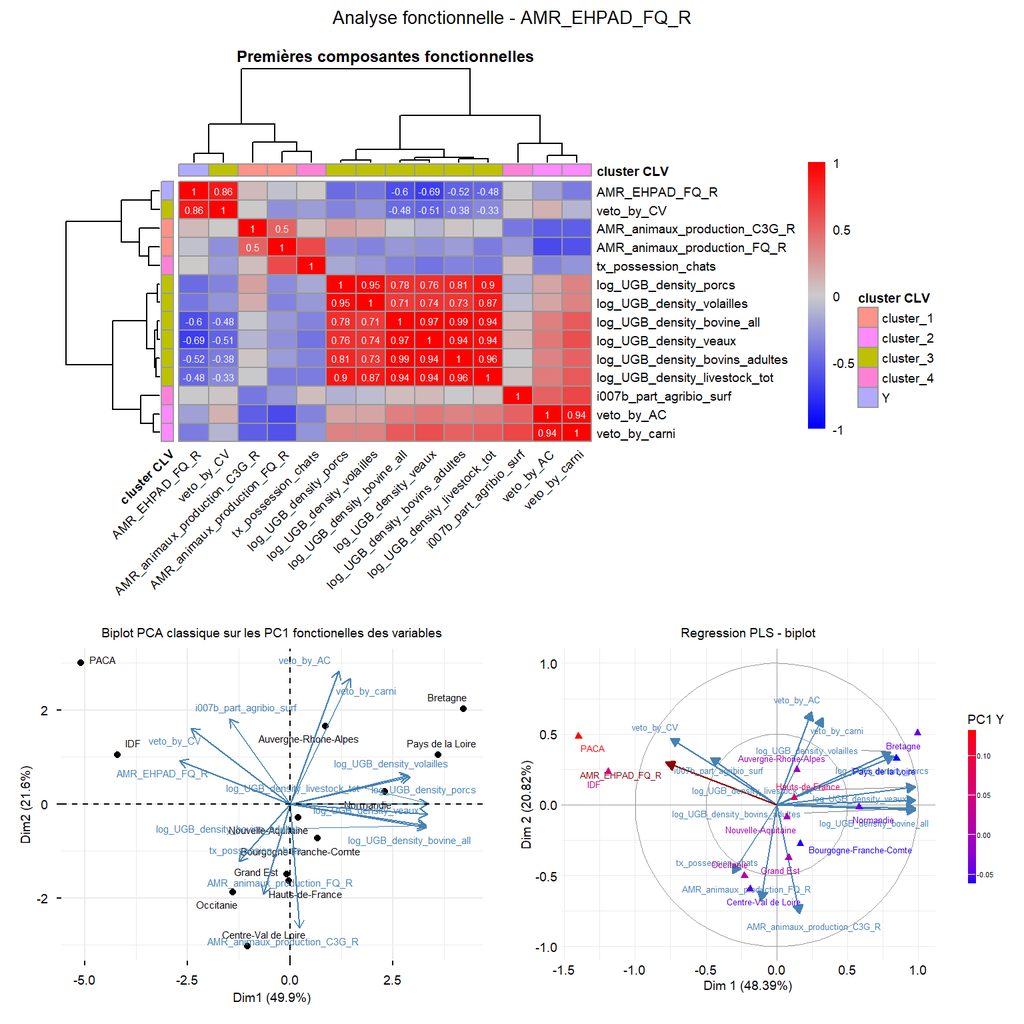

### 3.1.3 Environment

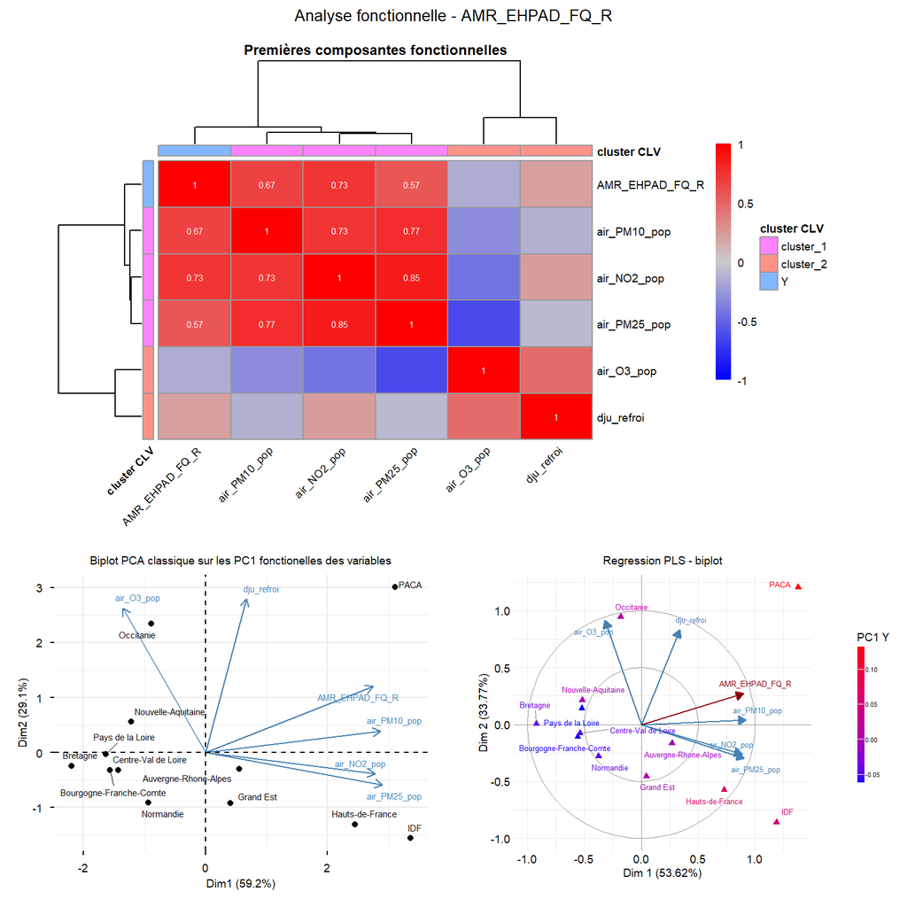

### 3.1.4 Humans

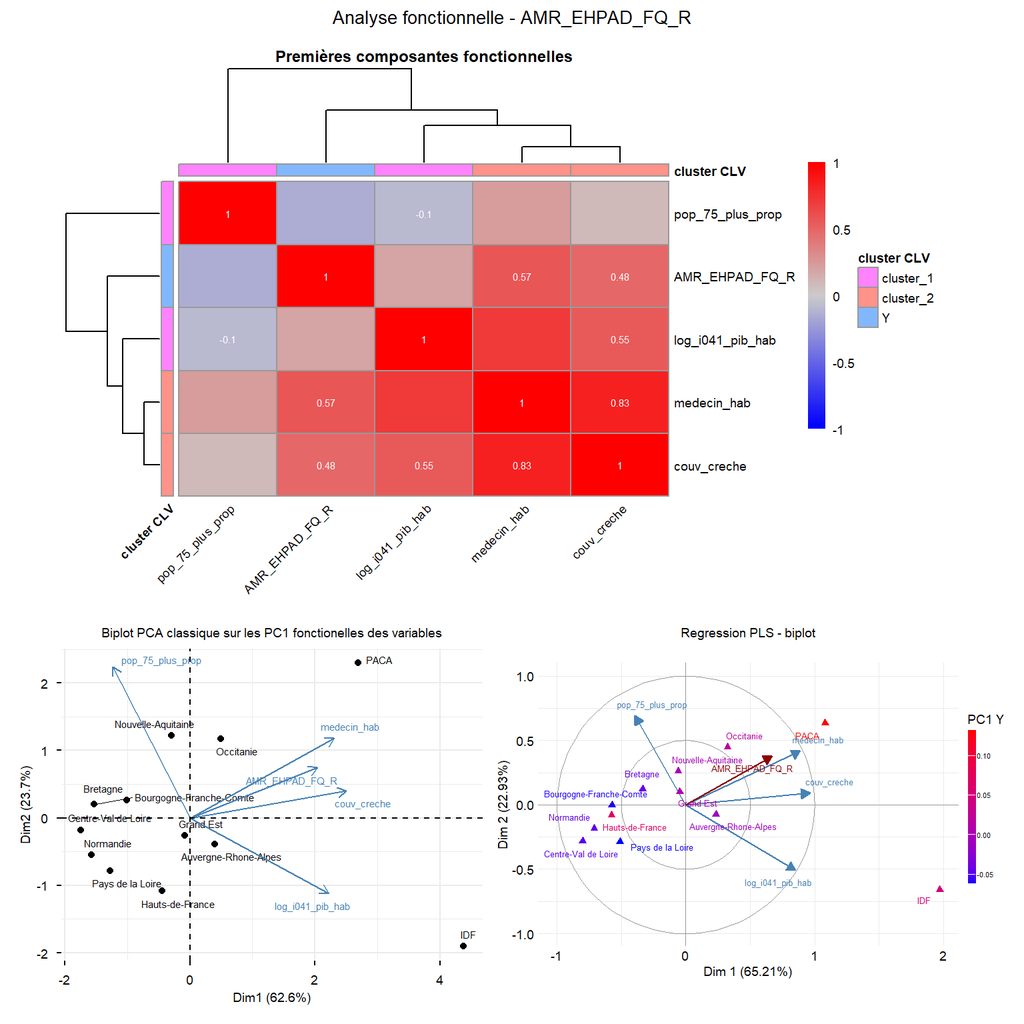

## 3.2 AMR_ES_FQ_R

```r
y <- "AMR_ES_FQ_R"
var <- selvar_AMR_ES_FQ$variable
Nb.Base <- 5

K = c(2, 3, NA, NA)
automatisation_block(y = y, blocks = blocks, var = var,
                     Nb.Base = Nb.Base, K_choice = K, metd = "directional")
```

### 3.2.1 AMC

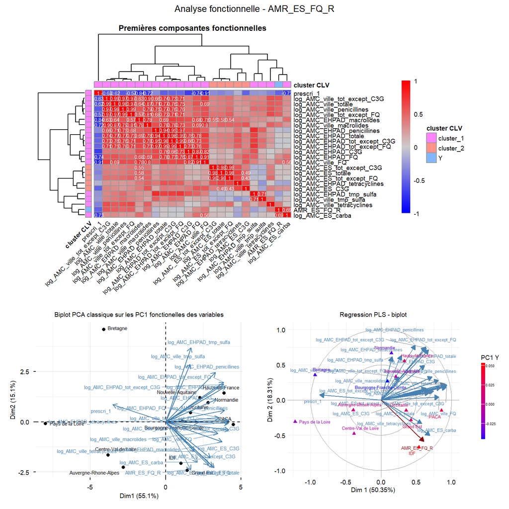

### 3.2.2 Animals

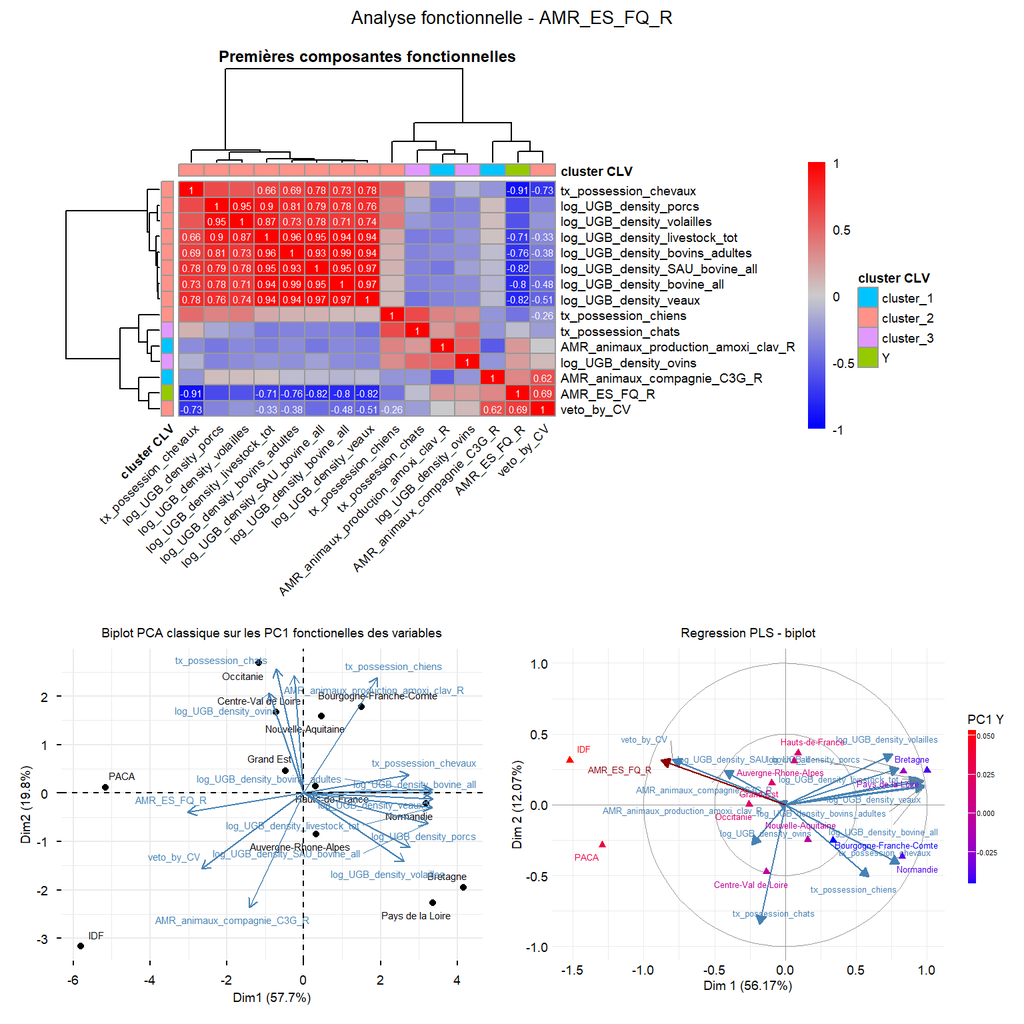

### 3.2.3 Environment

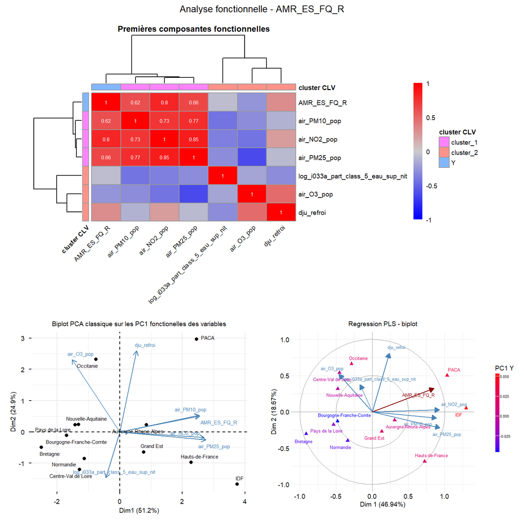

### 3.2.4 Humans

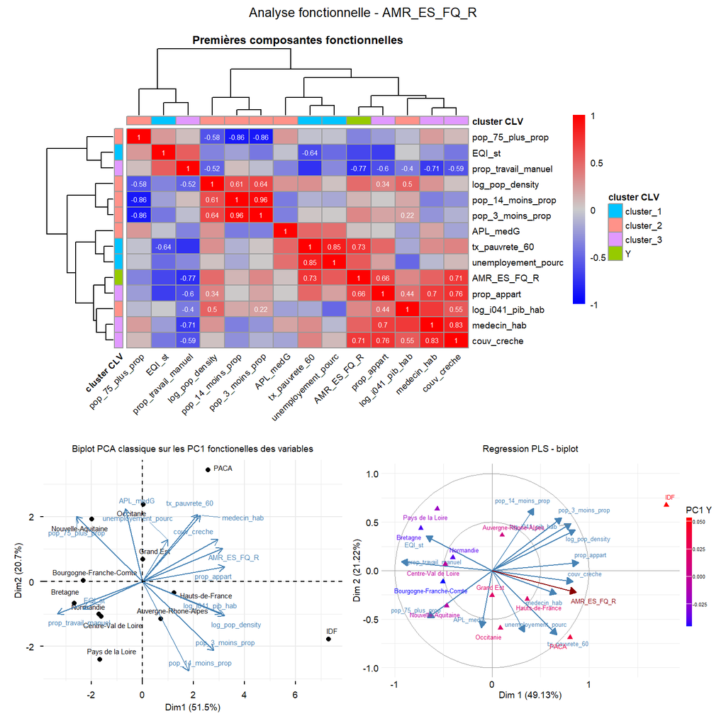

## 3.3 AMR_ville_FQ_R

```r
y <- "AMR_ville_FQ_R"
var <- selvar_AMR_ville_FQ$variable
Nb.Base <- 5

K = c(2, 4, NA, NA)
automatisation_block(y = y, blocks = blocks, var = var,
                     Nb.Base = Nb.Base, K_choice = K, metd = "directional")
```

### 3.3.1 AMC

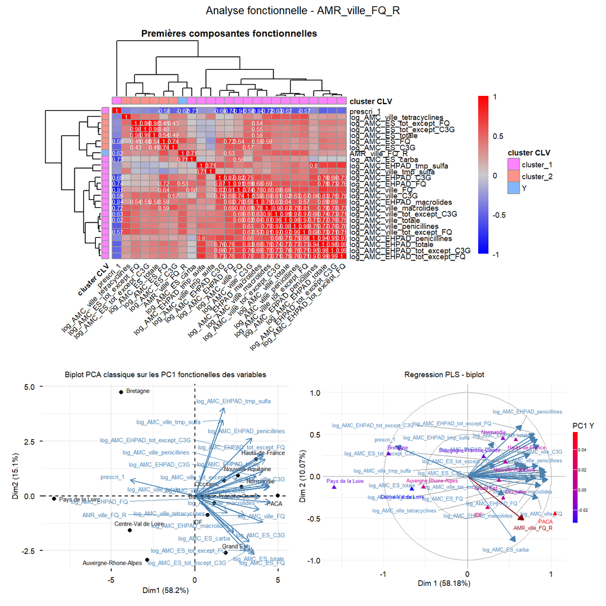

### 3.3.2 Animals

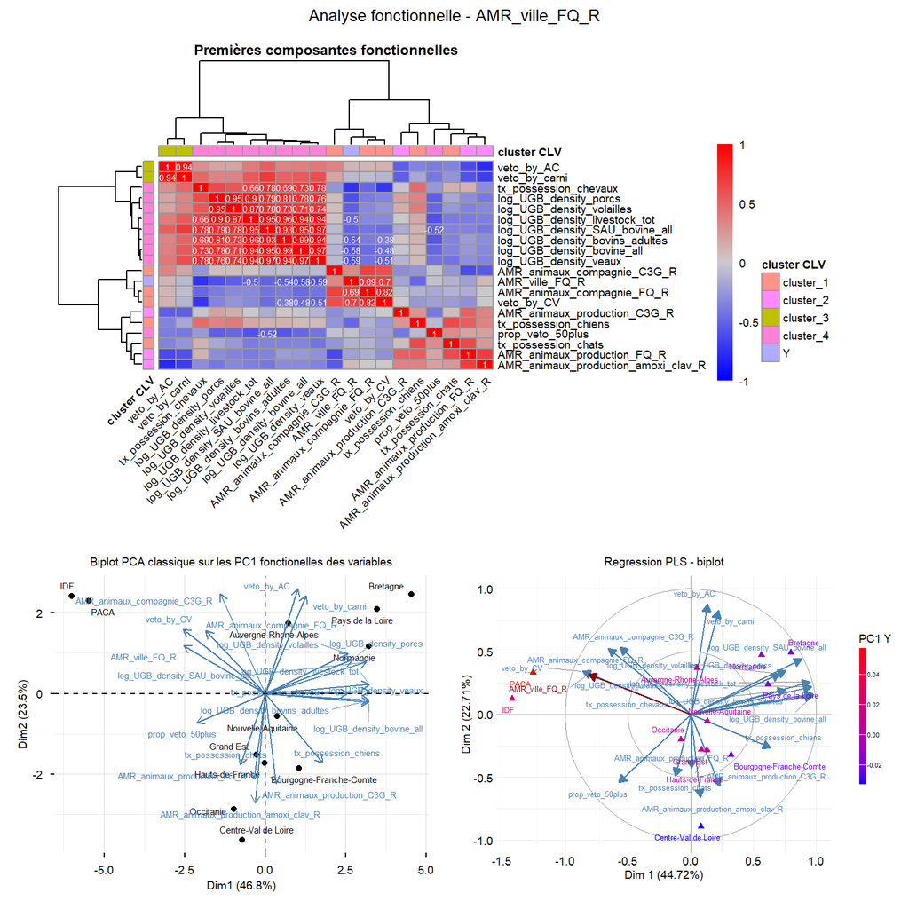

### 3.3.3 Environment

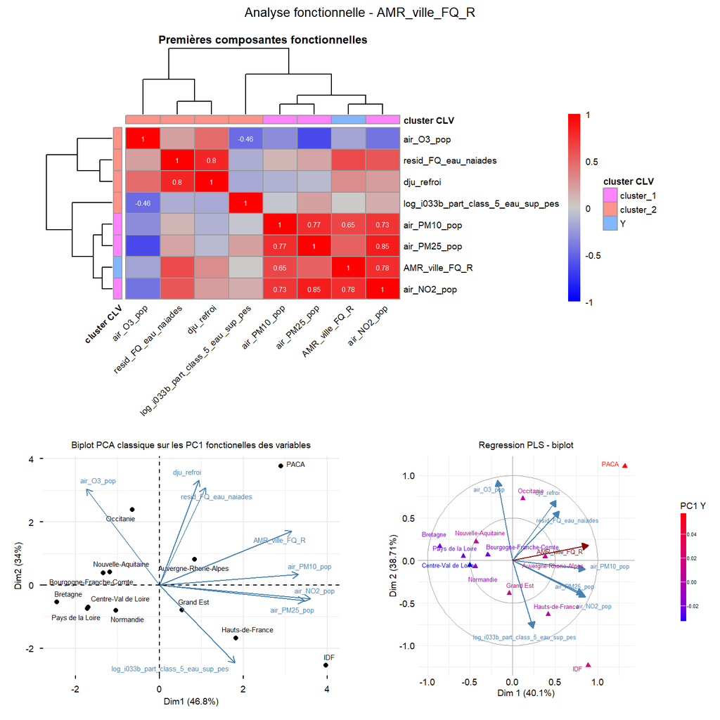

### 3.3.4 Humans

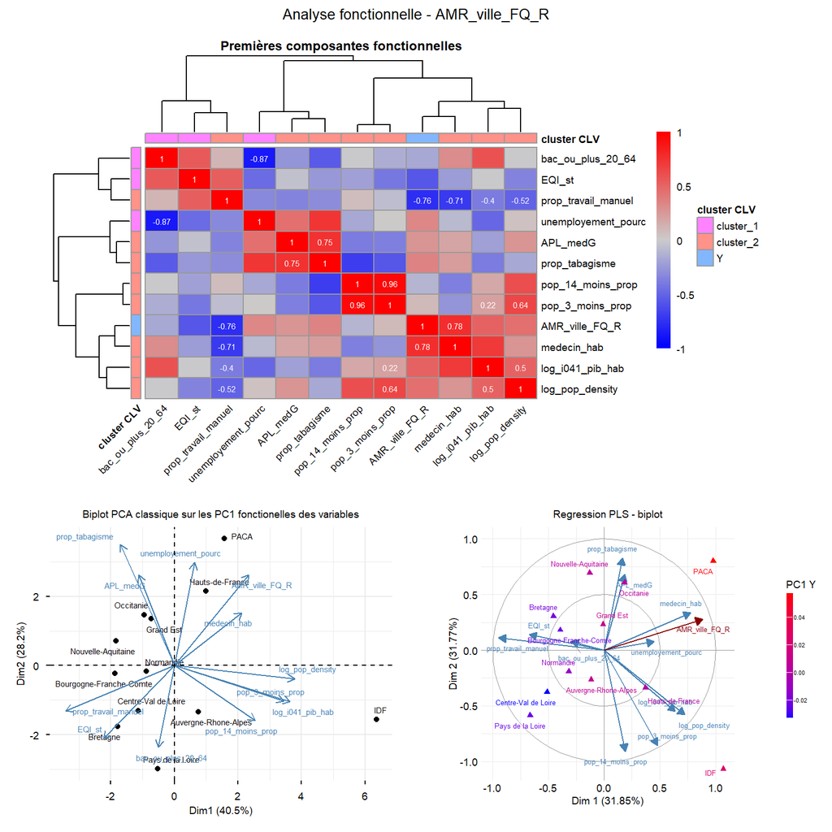

## 3.4 AMR_EHPAD_C3G_R

```r
y <- "AMR_EHPAD_C3G_R"
var <- selvar_AMR_EHPAD_C3G$variable
Nb.Base <- 5

K = c(NA, 3, rep(NA, 2))
automatisation_block(y = y, blocks = blocks, var = var,
                     Nb.Base = Nb.Base, K_choice = K, metd = "directional")
```

### 3.4.1 AMC

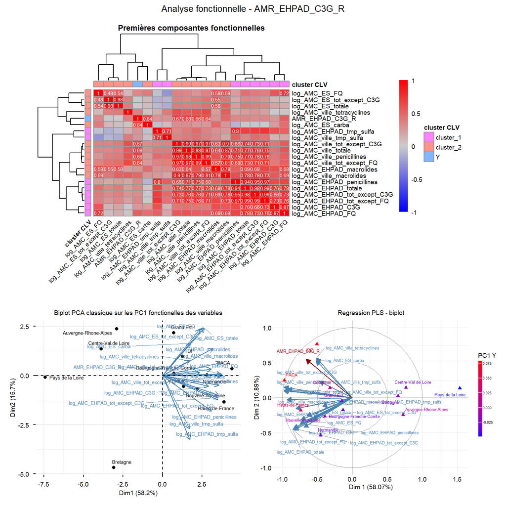

### 3.4.2 Animals

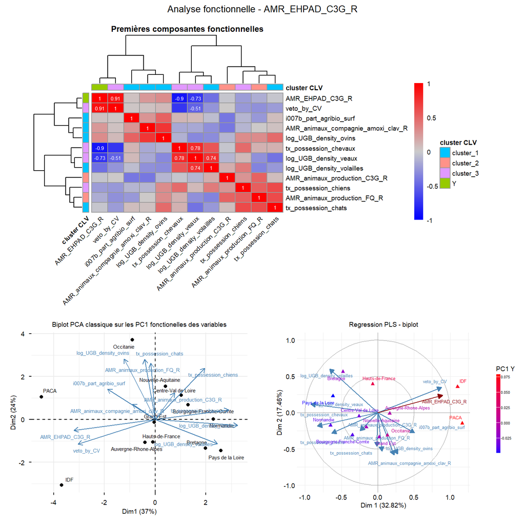

### 3.4.3 Environment

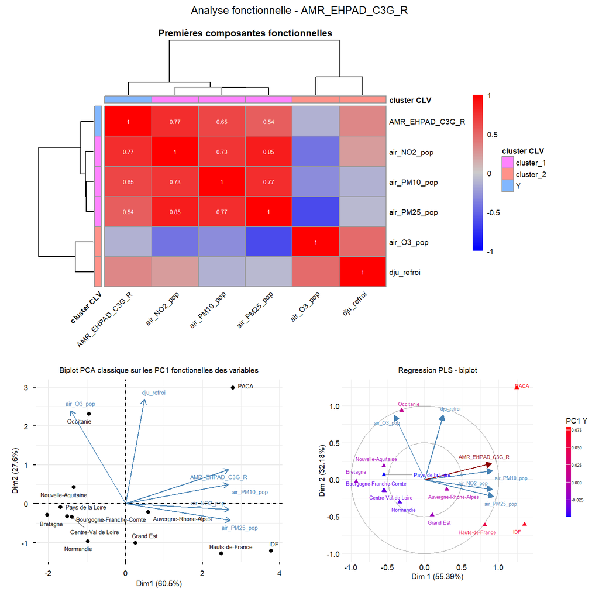

### 3.4.4 Humans

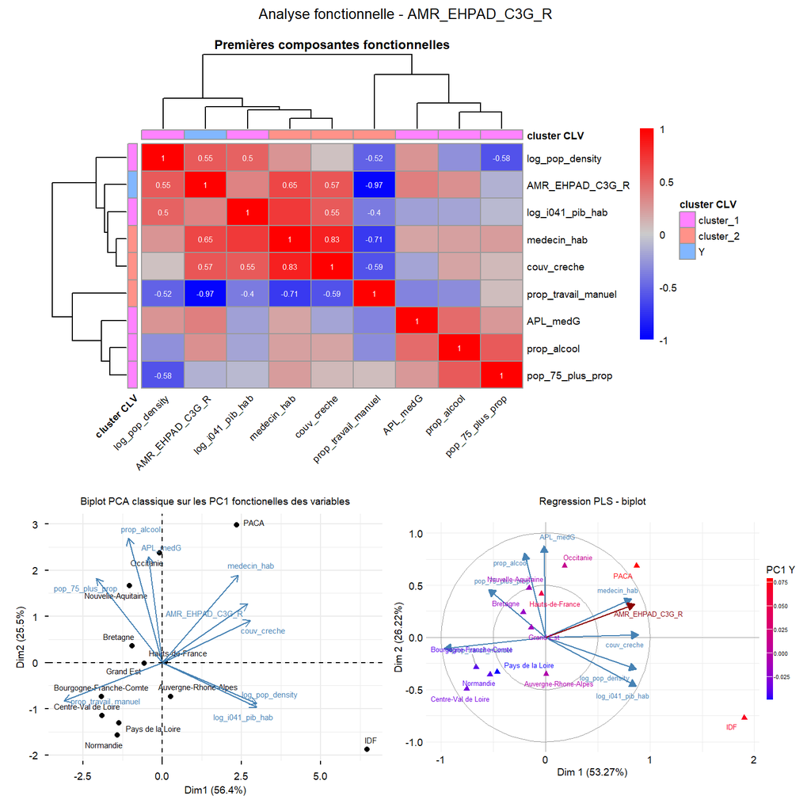

## 3.5 AMR_ES_C3G_R

```r
y <- "AMR_ES_C3G_R"
var <- selvar_AMR_ES_C3G$variable
Nb.Base <- 4

automatisation_block(y = y, blocks = blocks, var = var,
                     Nb.Base = Nb.Base, K_choice = K, metd = "directional")
```

### 3.5.1 AMC

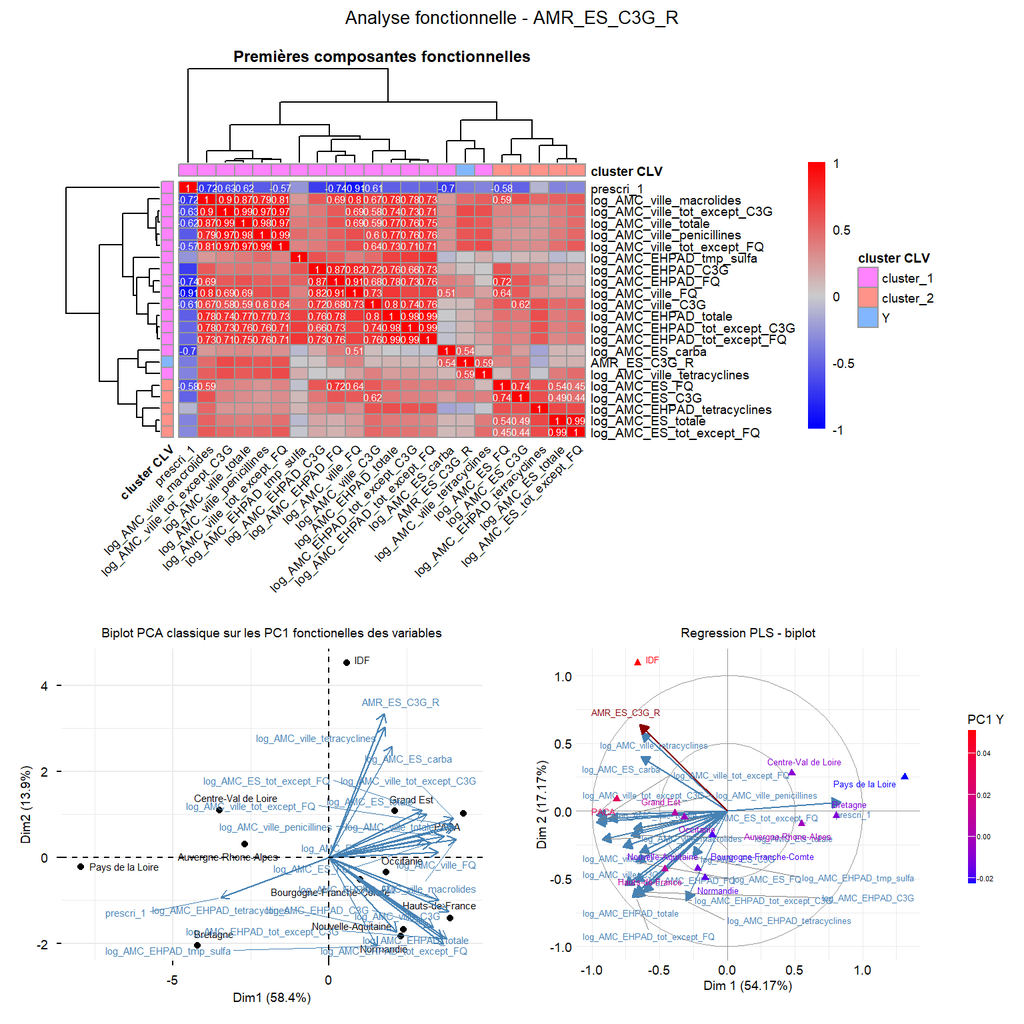

### 3.5.2 Animals

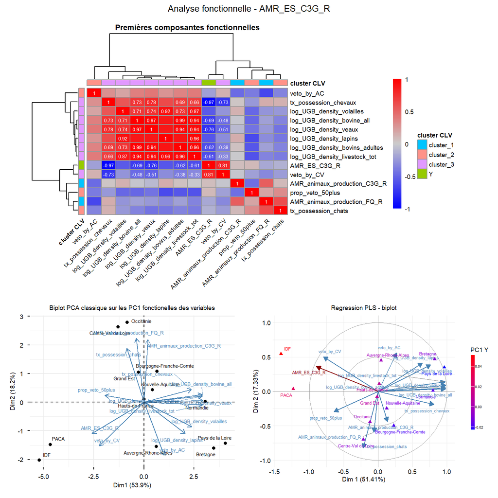

### 3.5.3 Environment

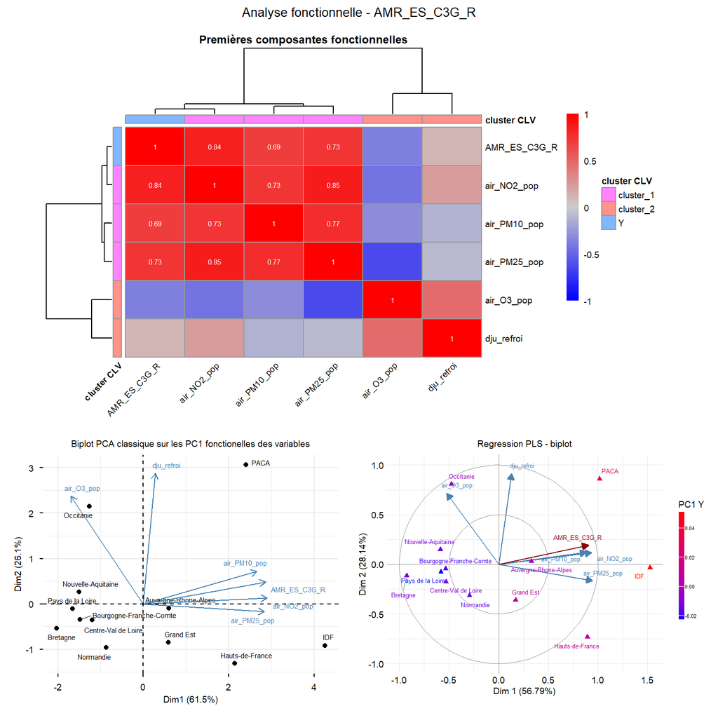

### 3.5.4 Humans

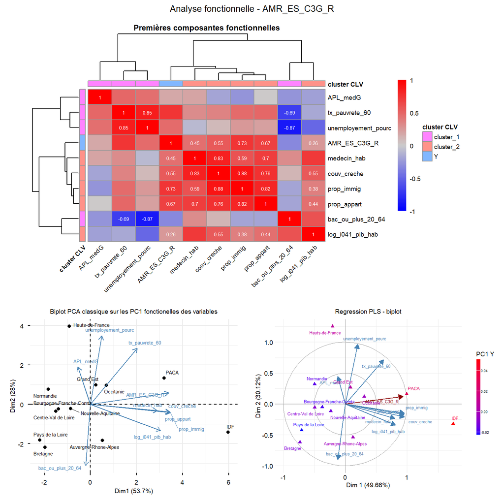

## 3.6 AMR_ville_C3G_R

```r
y <- "AMR_ville_C3G_R"
var <- selvar_AMR_ville_C3G$variable
Nb.Base <- 5

K = c(NA, 3, NA, 2)
automatisation_block(y = y, blocks = blocks, var = var,
                     Nb.Base = Nb.Base, K_choice = K, metd = "directional")
```

### 3.6.1 AMC

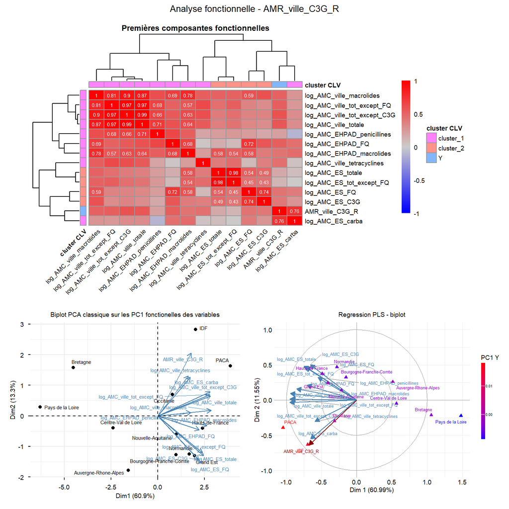

### 3.6.2 Animals

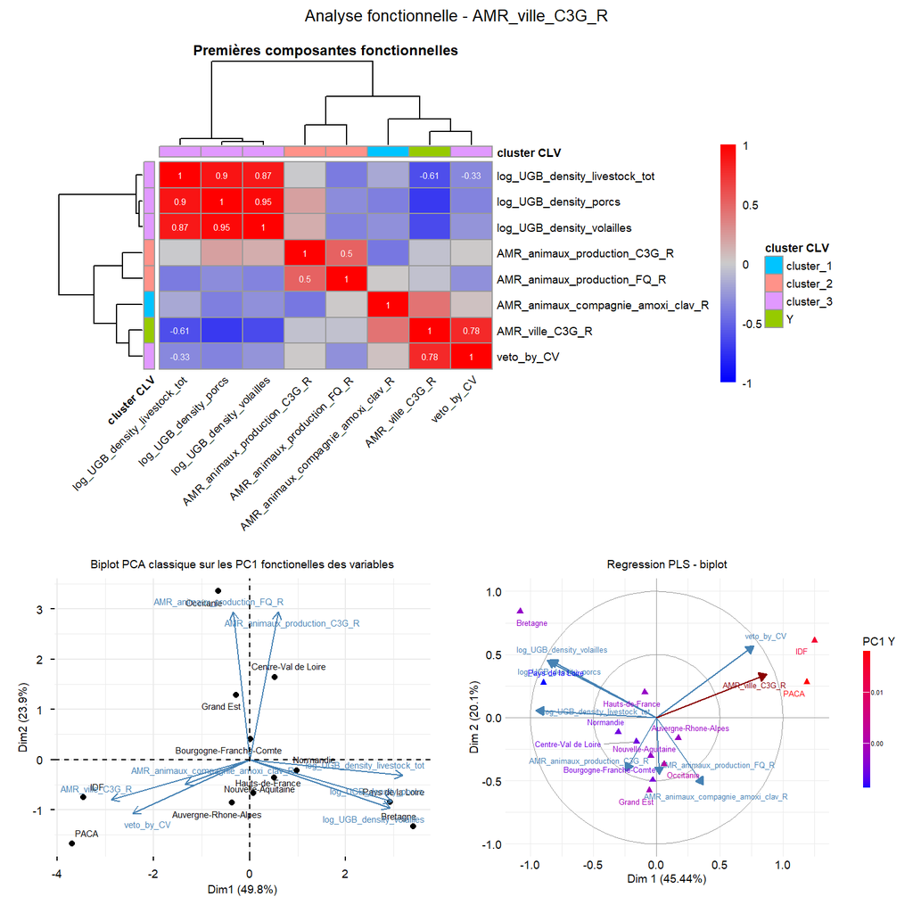

### 3.6.3 Environment

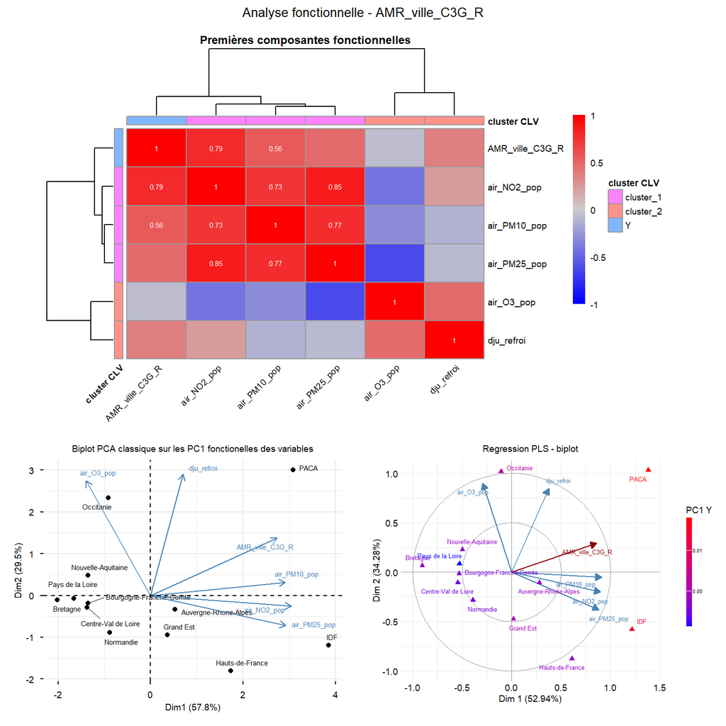

### 3.6.4 Humans

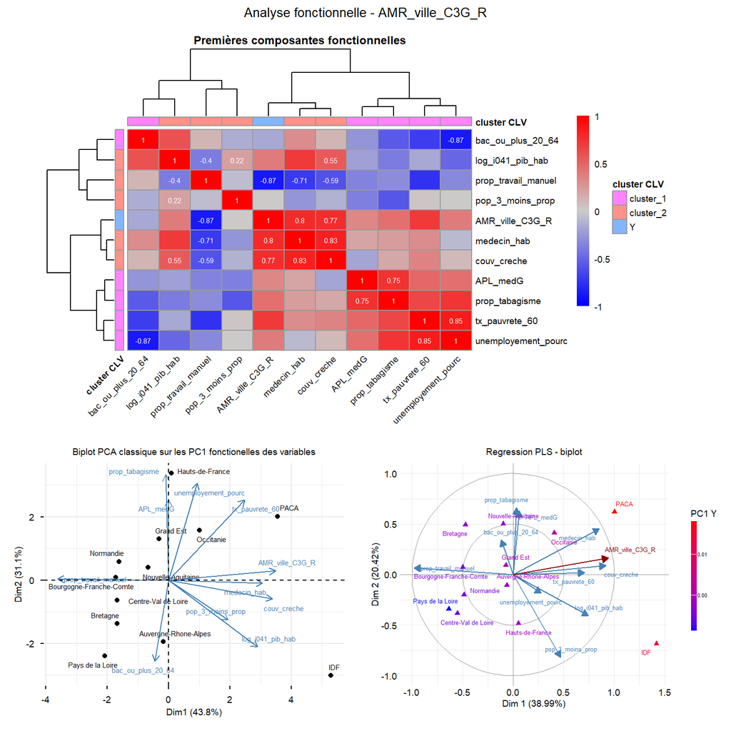

# 4 Tableau récapitulatif

```r
#importer les datasets
cls1 <- openxlsx::read.xlsx("C:/Users/g.martet/Documents/functional_study/cls.var_AMR_EHPAD_FQ_R.xlsx")
cls2 <- openxlsx::read.xlsx("C:/Users/g.martet/Documents/functional_study/cls.var_AMR_ES_FQ_R.xlsx")
cls3 <- openxlsx::read.xlsx("C:/Users/g.martet/Documents/functional_study/cls.var_AMR_ville_FQ_R.xlsx")
cls4 <- openxlsx::read.xlsx("C:/Users/g.martet/Documents/functional_study/cls.var_AMR_EHPAD_C3G_R.xlsx")
cls5 <- openxlsx::read.xlsx("C:/Users/g.martet/Documents/functional_study/cls.var_AMR_ES_C3G_R.xlsx")
cls6 <- openxlsx::read.xlsx("C:/Users/g.martet/Documents/functional_study/cls.var_AMR_ville_C3G_R.xlsx")

# let's go
big_tab <- correspondance_block
big_tab <- dplyr::left_join(big_tab, cls1, by = "variable")
big_tab <- dplyr::left_join(big_tab, cls2, by = "variable")
big_tab <- dplyr::left_join(big_tab, cls3, by = "variable")
big_tab <- dplyr::left_join(big_tab, cls4, by = "variable")
big_tab <- dplyr::left_join(big_tab, cls5, by = "variable")
big_tab <- dplyr::left_join(big_tab, cls6, by = "variable")

openxlsx::write.xlsx(big_tab, file = "tableau_recapitulatif_clustvar.xlsx")

# représenter le tableau de manière jolie

# Palette de couleurs par cluster
cluster_colors <- c(
  "cluster_1" = "#AED6F1",  # bleu clair
  "cluster_2" = "#A9DFBF",  # vert clair
  "cluster_3" = "#F9E79F",  # jaune clair
  "cluster_4" = "#F5CBA7"   # orange clair
)

# Fonction pour colorier une cellule selon sa valeur
color_cell <- function(x) {
  x <- as.character(x)  # convertit NA en "NA" string
  dplyr::case_when(
    is.na(x) | x == "NA" ~ cell_spec(" ", background = "white",  color = "white"),
    x == "cluster_1"      ~ cell_spec(x,   background = "#AED6F1", color = "black"),
    x == "cluster_2"      ~ cell_spec(x,   background = "#A9DFBF", color = "black"),
    x == "cluster_3"      ~ cell_spec(x,   background = "#F9E79F", color = "black"),
    x == "cluster_4"      ~ cell_spec(x,   background = "#F5CBA7", color = "black"),
    TRUE                  ~ x
  )
}
# Appliquer la coloration sur toutes les colonnes de cluster
cols_cluster <- colnames(big_tab)[!(colnames(big_tab) %in% c("block", "variable"))]

big_tab_colored <- big_tab %>%
  dplyr::mutate(dplyr::across(dplyr::all_of(cols_cluster), color_cell))

# Taille des groupes par block (pour pack_rows)
order_blocks <- c("AMC", "Animals", "Environment", "Humans")

group_sizes <- big_tab %>%
  dplyr::mutate(block = factor(block, levels = order_blocks)) %>%
  dplyr::arrange(block) %>%
  dplyr::group_by(block) %>%
  dplyr::summarise(n = n()) %>%
  tibble::deframe()


# Construction du tableau
big_tab_colored %>%
  dplyr::mutate(block = factor(block, levels = order_blocks)) %>%
  dplyr::arrange(block) %>%
  dplyr::select(-block) %>%
  kable(format = "html", escape = FALSE,
        col.names = c("Variable", cols_cluster),
        align = c("l", rep("c", length(cols_cluster)))) %>%
  kable_styling(bootstrap_options = c("striped", "hover", "condensed", "bordered"),
                full_width = FALSE,
                font_size = 11) %>%
  # Groupes par block
  pack_rows(index = group_sizes,
            label_row_css = "background-color: #2C3E50; color: white; font-weight: bold;") %>%
  column_spec(1, bold = TRUE, width = "12em") %>%
  scroll_box(width = "100%", height = "600px")
```

| Variable | AMR_EHPAD_FQ_R | AMR_ES_FQ_R | AMR_ville_FQ_R | AMR_EHPAD_C3G_R | AMR_ES_C3G_R | AMR_ville_C3G_R |
| --- | --- | --- | --- | --- | --- | --- |
| **AMC** |  |  |  |  |  |  |
| log_AMC_EHPAD_C3G | cluster_1 | cluster_1 | cluster_1 | cluster_1 | cluster_1 |  |
| log_AMC_EHPAD_FQ | cluster_1 | cluster_1 | cluster_1 | cluster_1 | cluster_1 | cluster_1 |
| log_AMC_EHPAD_macrolides | cluster_2 | cluster_1 | cluster_1 | cluster_2 |  | cluster_1 |
| log_AMC_EHPAD_penicillines | cluster_1 | cluster_1 | cluster_1 | cluster_1 |  | cluster_1 |
| log_AMC_EHPAD_tetracyclines | cluster_3 | cluster_2 |  |  | cluster_2 |  |
| log_AMC_EHPAD_tmp_sulfa |  | cluster_1 | cluster_1 | cluster_1 | cluster_1 |  |
| log_AMC_EHPAD_tot_except_C3G | cluster_1 | cluster_1 | cluster_1 | cluster_1 | cluster_1 |  |
| log_AMC_EHPAD_totale | cluster_1 | cluster_1 | cluster_1 | cluster_1 | cluster_1 |  |
| log_AMC_ES_FQ | cluster_3 |  | cluster_2 | cluster_2 | cluster_2 | cluster_2 |
| log_AMC_ES_carba | cluster_2 | cluster_1 | cluster_1 | cluster_2 | cluster_1 | cluster_1 |
| log_AMC_ES_C3G | cluster_3 | cluster_2 | cluster_2 |  | cluster_2 | cluster_2 |
| log_AMC_ES_tot_except_C3G | cluster_3 | cluster_2 | cluster_2 | cluster_2 |  |  |
| log_AMC_ES_totale | cluster_3 | cluster_2 | cluster_2 | cluster_2 | cluster_2 | cluster_2 |
| log_AMC_ville_C3G | cluster_1 |  | cluster_1 |  | cluster_1 |  |
| log_AMC_ville_FQ | cluster_2 | cluster_1 | cluster_1 |  | cluster_1 |  |
| log_AMC_ville_macrolides | cluster_2 | cluster_1 | cluster_1 | cluster_2 | cluster_1 | cluster_1 |
| log_AMC_ville_penicillines | cluster_2 | cluster_1 | cluster_1 | cluster_2 | cluster_1 |  |
| log_AMC_ville_tetracyclines | cluster_2 | cluster_1 | cluster_2 | cluster_2 | cluster_1 | cluster_1 |
| log_AMC_ville_tmp_sulfa | cluster_2 | cluster_1 | cluster_1 | cluster_1 |  |  |
| log_AMC_ville_tot_except_C3G | cluster_2 | cluster_1 | cluster_1 | cluster_2 | cluster_1 | cluster_1 |
| log_AMC_ville_totale | cluster_2 | cluster_1 | cluster_1 | cluster_2 | cluster_1 | cluster_1 |
| log_AMC_EHPAD_tot_except_FQ | cluster_1 | cluster_1 | cluster_1 | cluster_1 | cluster_1 |  |
| log_AMC_ES_tot_except_FQ |  | cluster_2 | cluster_2 |  | cluster_2 | cluster_2 |
| log_AMC_ville_tot_except_FQ | cluster_2 | cluster_1 | cluster_1 | cluster_2 | cluster_1 | cluster_1 |
| prescri_1 | cluster_2 | cluster_1 | cluster_1 |  | cluster_1 |  |
| prescri_5_inv |  |  |  |  |  |  |
| prescri_9_inv | cluster_3 |  |  |  |  |  |
| prescri_12_inv |  |  |  |  |  |  |
| **Animals** |  |  |  |  |  |  |

[output cut: 60 more lines]

# 5 Régression (r)GSCA

L’idée ici est d’explorer la relation entre les différents blocs des premières composantes fonctionnelles de chaque variable. Nous allons utiliser pour cela la méthode GSCA (H. Hwang, Y. Takane, Generalized structured component analysis, Psychometrika 69 (2004) 81–99) avec le package R `gesca`(v 1.0.5). Nous allons utiliser un modèle réflectif, c’est à dire que chaque bloc sera caractérisé par une composante principale qui sera à la fois, une combinaison linéaire des PC1 fonctionelles ($t_k = X_kw_k$) et un prédicteur des variables d’origines ($X_k = t_kc_k$). Les relations entre les blocks sont modélisées sur le schéma ci-dessous.

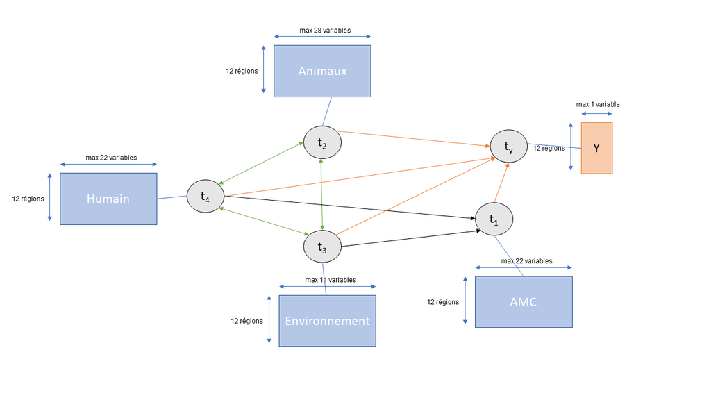

## 5.1 Toutes les variables

On regarde ce que donne une GSCA pour **Y = AM_ville_FQ_R** en considérant toutes les variables de tous les blocks dans l’étape avant clusters (c’est à dire les variables séléctionnées avec les GEEs).

**Mauvaise nouvelle**: le modèle est beaucoup trop complexe pour le peu d’individu qu’on a. il y a beaucoup plus de paramètres à estimer (poids + paths coeffs + loadings) que d’individus. Cependant on peut voir que les poucentages de variances expliqués par les PC1 de chaque blocks sont relativement élevés, surtout pour le block AMC. On peut considérer que le block AMC est unidimensionnel. Pour le reste l’étape de sélection des variables reste indispensable.

```r
dat.func1 <- openxlsx::read.xlsx("sum.var_AMR_ville_FQ_R.xlsx")
rownames(dat.func1) <- dat.func1[, 1]
dat.func1 <- dat.func1[,-1]
dat.func1 <- scale(dat.func1) # standardisation

var_AMC <- colnames(dat.func1)[which(colnames(dat.func1) %in% correspondance_block[correspondance_block$block == "AMC",]$variable)]
var_Animals <- colnames(dat.func1)[which(colnames(dat.func1) %in% correspondance_block[correspondance_block$block == "Animals",]$variable)]
var_Environment <- colnames(dat.func1)[which(colnames(dat.func1) %in% correspondance_block[correspondance_block$block == "Environment",]$variable)]
var_Humans <- colnames(dat.func1)[which(colnames(dat.func1) %in% correspondance_block[correspondance_block$block == "Humans",]$variable)]



MyModel <- paste(
  paste("Y =~", colnames(dat.func1)[1]),
  paste0("AMC =~ ", paste(var_AMC, collapse = " + ")),
  paste0("Animals =~ ", paste(var_Animals, collapse = " + ")),
  paste0("Environment =~ ", paste(var_Environment, collapse = " + ")),
  paste0("Humans =~ ", paste(var_Humans, collapse = " + ")),
  "Y ~ AMC + Animals + Environment + Humans",
  "AMC ~ Humans + Environment",
  "Environment ~ Animals + Humans",
  "Humans ~ Environment + Animals",
  "Animals ~ Environment + Humans",
  sep = "\n\t\t"
)

# Hypothèse d'unidimensionalité des blocks
Xnorm.block <- list(dat.func1[,which(colnames(dat.func1) %in% var_AMC)],
                    dat.func1[,which(colnames(dat.func1) %in% var_Animals)],
                    dat.func1[,which(colnames(dat.func1) %in% var_Environment)],
                    dat.func1[,which(colnames(dat.func1) %in% var_Humans)]
                    )

nb.block <- length(Xnorm.block)
order_blocks <- c("AMC", "Animals", "Environment", "Humans")
eigen <- lapply(1:nb.block, function(k) FactoMineR::PCA(Xnorm.block[[k]], scale.unit = TRUE, ncp = 2, graph = F)$eig)
perc_var_comp1 <- c()
for(i in 1:nb.block){
  perc_var_comp1 <- c(perc_var_comp1, eigen[[i]][1,2])
}
df.unim <- data.frame(order_blocks,
                      percentage_variance_PCA_comp1 = round(perc_var_comp1, 2))
knitr::kable(df.unim)
```

| order_blocks | percentage_variance_PCA_comp1 |
| --- | --- |
| AMC | 59.07 |
| Animals | 46.41 |
| Environment | 46.55 |
| Humans | 41.99 |

```r
# Le modèle
# set.seed(123)
#mod <- gesca::gesca.run(MyModel, dat.func1, nbt = 0)
```